#### Khoa Điện tử Viễn thông- Trường Đại học Khoa học tự nhiên

# Bài 5: THIẾT KẾ LỌC IIR

Nhóm: Ca02

Họ và tên: Nguyễn Anh Tuấn MSSV: 20200399

#### Mục đích:

> - Xác định được các thông số bộ lọc cần thiết kế
> - Thiết kế được bộ lọc IIR
> - Phân tích tích tín hiệu trước và sau lọc

## Tóm tắt lý thuyết :

Để thiết kế lọc IIR ta sử dụng các phương pháp sau:

1. Sử dụng hàm signal.iirfilter() $b, a = iirfilter(N, Wn, rp=None, rs=None, btype='band', analog=False, ftype='butter', output='ba')$  
   Trong đó:

   > *N*: Bậc lọc  
   > *Wn*: Là tần số góc chuẩn hóa có giá trị từ 0 -> 1. Đơn vị là rad/mẫu (lọc số) rad/s (lọc tương tự). Khi tần số cắt bằng tần số nyquist thì Wn = 1.  
   > *rp*: Độ dợn sóng tối đa dải qua (dB) (Đối với lọc Chebyshev và elliptic)  
   > *rs*: Độ dợn sóng tối thiểu ở dải chặn (dB) (Đối với lọc Chebyshev và elliptic)  
   > *btype*: Loại lọc: 'bandpass’, ‘lowpass’, ‘highpass’, ‘bandstop’  
   > *analog*: Chọn loại lọc số hay lọc tương tự mặc định là lọc số  
   > *ftype*: Loại lọc IIR cần thiết kế
> > - Butterworth : ‘butter’
> > - Chebyshev I : ‘cheby1’
> > - Chebyshev II : ‘cheby2’
> > - Cauer/elliptic: ‘ellip’
> > - Bessel/Thomson: ‘bessel’

> > *output* : Mặc định là tạo ra các hệ số b, a
1. Sử dụng hàm signal.iirdesign() $$b, a = signal.iirdesign(wp, ws, gpass, gstop, analog=False, ftype= 'ellip', output = 'ba')$$ Trong đó:

   > wp, ws: là tần số chuẩn hóa ở dải qua và tần số cắt chuẩn hóa ở dải chặn. Ví dụ:
> > - Lowpass: wp = 0.2, ws = 0.3
> > - Highpass: wp = 0.3, ws = 0.2
> > - Bandpass: wp = [0.2, 0.5], ws = [0.1, 0.6]
> > - Bandstop: wp = [0.1, 0.6], ws = [0.2, 0.5]

> > *gpass*: Độ dợn sóng dải qua (dB)  
> > *gstop*: Độ dợn sóng dải chặn (dB)  
> > *analog*: Chọn loại lọc số hay lọc tương tự mặc định là lọc số  
> > *ftype*: Loại lọc IIR cần thiết kế
> > - Butterworth : ‘butter’
> > - Chebyshev I : ‘cheby1’
> > - Chebyshev II : ‘cheby2’
> > - Cauer/elliptic: ‘ellip’
> > - Bessel/Thomson: ‘bessel’

> > *output* : Mặc định là tạo ra các hệ số b, a
1. Thiết kể theo kiểu Matlab Các hàm có cú pháp giống trong Matlab  
   Ví dụ:
> - Thiết kế lọc Butterword:  
>   N, Wn = signal.buttord(wp, ws, gpass, gstop, analog=False)  
>   b, a = signal.butter(N, Wn, btype='low', analog=False, output='ba')
> - Thiết kế lọc Chebyshev loại 1 N, Wn = signal.cheb1ord(wp, ws, gpass, gstop, analog=False)  
>   b, a = signal.cheby1(N, rp, Wn, btype='low', analog=False, output='ba')
> - Tương tự đối với Chebyshev loại 2, Elliptic

Thêm thư viện vào project

```python
#Thêm thư viện
import matplotlib.pyplot as plt
from scipy import signal
import numpy as np
```

#### Bài 1a:

Chương trình sau đây thực hiện tạo ra lọc IIR dải qua Chebyshev loại 2, bậc 4 và vẽ đáp ứng tần số của lọc thiết kế được

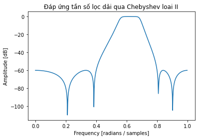

```python
b, a = signal.iirfilter(N = 4, Wn = [0.4, 0.8], rs=60, btype='band',
                        analog=False, ftype='cheby2')
w, H = signal.freqz(b, a, worN=512, whole = False)
plt.plot(w/np.pi, 20 * np.log10(abs(H)))
plt.title('Đáp ứng tần số lọc dải qua Chebyshev loai II')
plt.xlabel('Frequency [radians / samples]')
plt.ylabel('Amplitude [dB]')
```

#### Bài 1b:

Chương trình để thiết kế lọc IIR thấp qua Chebyschev loại 2, bậc 8, tần số cắt là 10Hz, rs = 60. Áp dụng bộ lọc lên tín hiệu x.  
a. Vẽ đáp ứng tần số bộ lọc  
b. Vẽ tín hiệu vào và ra trên 1 hình

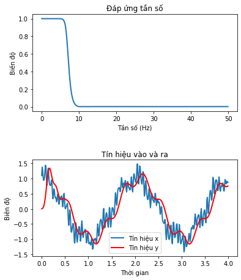

```python
sampleRate = 100 #Tần số lấy mẫu
nSamples = 400   #Số mẫu
t = np.arange(nSamples)/sampleRate #Khoảng thời gian
x = np.cos(2*np.pi*0.5*t) + 0.2*np.sin(2*np.pi*2.5*t+0.1) + \
        0.2*np.sin(2*np.pi*15.3*t) + 0.1*np.sin(2*np.pi*16.7*t + 0.1) + \
            0.1*np.sin(2*np.pi*23.45*t+.8)
nyquistRate = sampleRate/2 #Tần số Nyquist
cutOffFreq = 10 #Hz
#Viết tiếp chương trình ở đây
N = 8
wC = cutOffFreq/nyquistRate # Tần số cắt
b, a = signal.iirfilter(N, wC, rs=60, btype='low',analog=False, ftype='cheby2')
y = signal.lfilter(b, a, x)
w, H = signal.freqz(b,a, worN=512)
plt.subplot(2,1,1)
plt.plot((w/np.pi)*nyquistRate, abs(H), linewidth=2)
plt.title('Đáp ứng tần số')
plt.xlabel('Tần số (Hz)')
plt.ylabel('Biến độ')
plt.subplot(2,1,2)
plt.plot(t, x, linewidth=2, label = 'Tín hiệu x')
plt.title('Tín hiệu vào và ra')
plt.xlabel('Thời gian')
plt.ylabel('Biên độ')
plt.plot(t, y, 'r-', linewidth=2, label = 'Tín hiệu y')
plt.legend()#Hiển thị ghi chú
plt.subplots_adjust(top=1.5, hspace=0.5)
```

### Bài 2

Sử dụng hàm iirfilter() để thiết kế các mạch lọc sau

#### Bài 2a:

Thiết kế và vẽ đáp ứng tần số của mạch lọc IIR Butterworth thấp qua với các thông số sau:

- Tần số cắt 0.5 (rad/samples)
- Bậc lọc N = 8

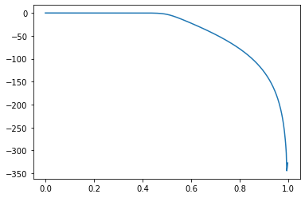

```python
sampleRate = 100 #Tần số lấy mẫu
nSamples = 400   #Số mẫu
t = np.arange(nSamples)/sampleRate #Khoảng thời gian
x = np.cos(2*np.pi*0.5*t) + 0.2*np.sin(2*np.pi*2.5*t+0.1) + \
        0.2*np.sin(2*np.pi*15.3*t) + 0.1*np.sin(2*np.pi*16.7*t + 0.1) + \
            0.1*np.sin(2*np.pi*23.45*t+.8)

b, a = signal.iirfilter(8, 0.5 ,rs=60, btype='low',analog=False, ftype='butter')
y = signal.lfilter(b, a, x)
w, H = signal.freqz(b,a, worN=512)
plt.plot(w/np.pi, 20 * np.log10(abs(H)))
```

#### Bài 2b:

Thiết kế và vẽ đáp ứng tần số của mạch lọc IIR Chebyshev loại 1 cao qua với các thông số sau:

- Tần số cắt 0.5 (rad/sapmles)
- Bậc lọc N = 8
- rs = 50, rp = 0.5

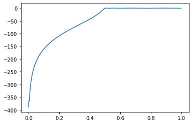

```python
x = np.cos(2*np.pi*0.5*t) + 0.2*np.sin(2*np.pi*2.5*t+0.1) + \
        0.2*np.sin(2*np.pi*15.3*t) + 0.1*np.sin(2*np.pi*16.7*t + 0.1) + \
            0.1*np.sin(2*np.pi*23.45*t+.8)
b, a = signal.iirfilter(8, 0.5, rp=0.5, rs=50, btype='highpass',analog=False, ftype='cheby1')
y = signal.lfilter(b, a, x)
w, H = signal.freqz(b,a, worN=512)
plt.plot(w/np.pi, 20 * np.log10(abs(H)))
```

#### Bài 2c:

Thiết kế và vẽ đáp ứng tần số của mạch lọc IIR Chebyshev loại 2 dải qua với các thông số sau:

- Tần số cắt [0.3 0.5] (rad/sapmles)
- Bậc lọc N = 8
- rs = 50, rp = 0.5

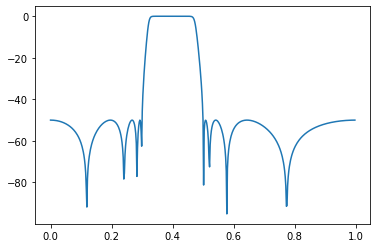

```python
x = np.cos(2*np.pi*0.5*t) + 0.2*np.sin(2*np.pi*2.5*t+0.1) + \
        0.2*np.sin(2*np.pi*15.3*t) + 0.1*np.sin(2*np.pi*16.7*t + 0.1) + \
            0.1*np.sin(2*np.pi*23.45*t+.8)
b, a = signal.iirfilter(8, Wn = [0.3, 0.5], rp=0.5, rs=50, btype='bandpass',analog=False, ftype='cheby2')
y = signal.lfilter(b, a, x)
w, H = signal.freqz(b,a, worN=512)
plt.plot(w/np.pi, 20 * np.log10(abs(H)))
```

#### Bài 2d:

Thiết kế và vẽ đáp ứng tần số của mạch lọc IIR Elliptic dải chặn với các thông số sau:

- Tần số cắt [0.3 0.5] (rad/sapmles)
- Bậc lọc N = 8
- rs = 50, rp = 0.5

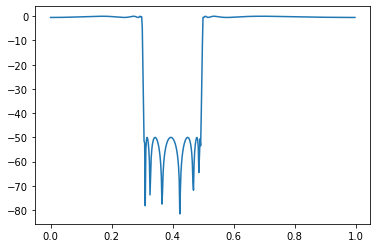

```python
x = np.cos(2*np.pi*0.5*t) + 0.2*np.sin(2*np.pi*2.5*t+0.1) + \
        0.2*np.sin(2*np.pi*15.3*t) + 0.1*np.sin(2*np.pi*16.7*t + 0.1) + \
            0.1*np.sin(2*np.pi*23.45*t+.8)
b, a = signal.iirfilter(8, Wn = [0.3, 0.5], rp=0.5, rs=50, btype='bandstop',analog=False, ftype='ellip')
y = signal.lfilter(b, a, x)
w, H = signal.freqz(b,a, worN=512)
plt.plot(w/np.pi, 20 * np.log10(abs(H)))
```

### Bài 3:

Sử dụng hàm iirdesign() để thiết kế các mạch lọc sau

#### Bài 3a:

Thiết kế và vẽ đáp ứng tần số của mạch lọc IIR Butterworth thấp qua với các thông số sau:

- Tần số cắt 0.5 (rad/sapmles)
- gpass = 0.5, gstop = 50

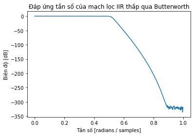

```python
wp = 0.5
ws = 0.6

b,a = signal.iirdesign(wp, ws, gpass=0.5, gstop=50, analog=False,ftype='butter')
w, h = signal.freqz(b,a, worN=512)

plt.plot(w/np.pi, 20 * np.log10(abs(h)))
plt.title('Đáp ứng tần số của mạch lọc IIR thấp qua Butterworth')
plt.xlabel('Tần số [radians / samples]')
plt.ylabel('Biên độ [dB]')
```

#### Bài 3b:

Thiết kế và vẽ đáp ứng tần số của mạch lọc IIR Chebyshev loại 1 cao qua với các thông số sau:

- Tần số cắt 0.5 (rad/sapmles)
- gstop = 50, pass = 0.5

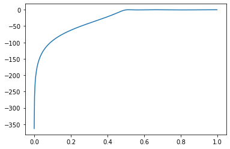

```python
wp = 0.5
ws = 0.2
b,a = signal.iirdesign(wp, ws, gpass=0.5, gstop=50, analog=False,ftype='cheby1')
w, h = signal.freqz(b,a, worN=512)
plt.plot(w/np.pi, 20 * np.log10(abs(h)))
```

#### Bài 3c:

Thiết kế và vẽ đáp ứng tần số của mạch lọc IIR Chebyshev loại 2 dải qua với các thông số sau:

- Tần số cắt [0.3 0.5] (rad/sapmles)
- gstop = 50, gpass = 0.5

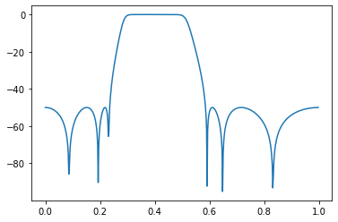

```python
wp = [0.3, 0.5]
ws = [0.1, 0.6]
b,a = signal.iirdesign(wp, ws, gpass=0.5, gstop=50, analog=False,ftype='cheby2')
w, h = signal.freqz(b,a, worN=512)
plt.plot(w/np.pi, 20 * np.log10(abs(h)))
```

#### Bài 3d:

Thiết kế và vẽ đáp ứng tần số của mạch lọc IIR Elliptic dải chặn với các thông số sau:

- Tần số cắt [0.3 0.5] (rad/sapmles)
- gstop = 50, gpass = 0.5

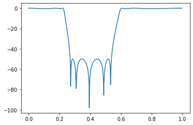

```python
wp = [0.1, 0.6]
ws = [0.3, 0.5]
b,a = signal.iirdesign(wp, ws, gpass=0.5, gstop=50, analog=False,ftype='ellip')
w, h = signal.freqz(b,a, worN=512)
plt.plot(w/np.pi, 20 * np.log10(abs(h)))
```

### Bài 4:

Thiết kế và vẽ đáp ứng tần số trên cùng 1 hình của các mạch lọc IIR thấp qua loại: Butterworth, Chebyshev loại 1, Chebyshev loại 2 và Elliptic với các thông số sau:

- Tần số cắt 0.5 (rad/sapmles)
- Bậc lọc N = 15
- gstop = 50, gpass = 0.5

Nhận xét về độ gợn sóng và độ rộng chuyển tiếp của các loại lọc

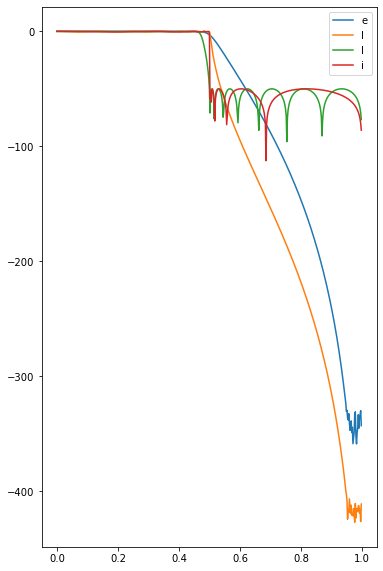

```python
b, a = signal.iirfilter(15, 0.5, rp = 0.5, rs=50, btype='low',analog=False, ftype='butter')
w, H = signal.freqz(b,a, worN=512)
plt.plot(w/np.pi, 20*np.log10(abs(H)))
plt.legend('butter')

b, a = signal.iirfilter(15, 0.5, rp = 0.5, rs=50, btype='low',analog=False, ftype='cheby1')
w, H = signal.freqz(b,a, worN=512)
plt.plot(w/np.pi, 20*np.log10(abs(H)))
plt.legend('cheby1')

b, a = signal.iirfilter(15, 0.5, rp = 0.5, rs=50, btype='low',analog=False, ftype='cheby2')
w, H = signal.freqz(b,a, worN=512)
plt.plot(w/np.pi, 20*np.log10(abs(H)))
plt.legend('cheby2')

b, a = signal.iirfilter(15, 0.5, rp = 0.5, rs=50, btype='low',analog=False, ftype='ellip')
w, H = signal.freqz(b,a, worN=512)
plt.plot(w/np.pi, 20*np.log10(abs(H)))
plt.legend('ellip')
plt.subplots_adjust(top = 2, hspace=0.5)
```

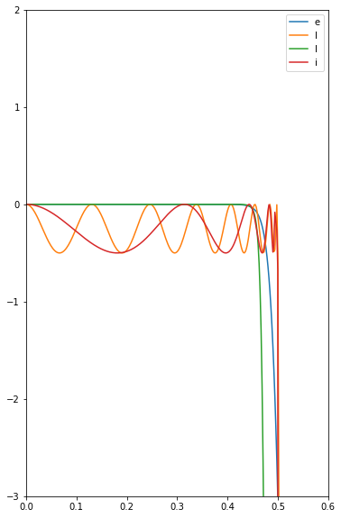

```python
#Giới hạn y để xem độ gợn sóng dải qua plt.xlim(0, 0.6) plt.ylim(-3, 2)
b, a = signal.iirfilter(15, 0.5, rp = 0.5, rs=50, btype='low',analog=False, ftype='butter')
w, H = signal.freqz(b,a, worN=512)
plt.plot(w/np.pi, 20*np.log10(abs(H)))
plt.legend('butter')

b, a = signal.iirfilter(15, 0.5, rp = 0.5, rs=50, btype='low',analog=False, ftype='cheby1')
w, H = signal.freqz(b,a, worN=512)
plt.plot(w/np.pi, 20*np.log10(abs(H)))
plt.legend('cheby1')

b, a = signal.iirfilter(15, 0.5, rp = 0.5, rs=50, btype='low',analog=False, ftype='cheby2')
w, H = signal.freqz(b,a, worN=512)
plt.plot(w/np.pi, 20*np.log10(abs(H)))
plt.legend('cheby2')

b, a = signal.iirfilter(15, 0.5, rp = 0.5, rs=50, btype='low',analog=False, ftype='ellip')
w, H = signal.freqz(b,a, worN=512)
plt.plot(w/np.pi, 20*np.log10(abs(H)))
plt.legend('ellip')
plt.xlim(0, 0.6)
plt.ylim(-3, 2)
plt.subplots_adjust(top = 2, hspace=0.5)
```

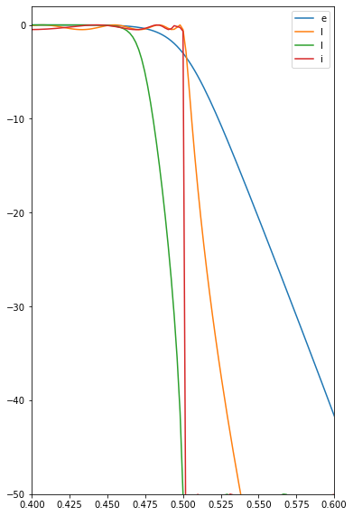

```python
#Giới hạn để xem độ rộng chuyển tiếp plt.xlim(0.4, 0.6) plt.ylim(-50, 2)
b, a = signal.iirfilter(15, 0.5, rp = 0.5, rs=50, btype='low',analog=False, ftype='butter')
w, H = signal.freqz(b,a, worN=512)
plt.plot(w/np.pi, 20*np.log10(abs(H)))
plt.legend('butter')

b, a = signal.iirfilter(15, 0.5, rp = 0.5, rs=50, btype='low',analog=False, ftype='cheby1')
w, H = signal.freqz(b,a, worN=512)
plt.plot(w/np.pi, 20*np.log10(abs(H)))
plt.legend('cheby1')

b, a = signal.iirfilter(15, 0.5, rp = 0.5, rs=50, btype='low',analog=False, ftype='cheby2')
w, H = signal.freqz(b,a, worN=512)
plt.plot(w/np.pi, 20*np.log10(abs(H)))
plt.legend('cheby2')

b, a = signal.iirfilter(15, 0.5, rp = 0.5, rs=50, btype='low',analog=False, ftype='ellip')
w, H = signal.freqz(b,a, worN=512)
plt.plot(w/np.pi, 20*np.log10(abs(H)))
plt.legend('ellip')
plt.xlim(0.4, 0.6)
plt.ylim(-50, 2)
plt.subplots_adjust(top = 2, hspace=0.5)
```

### Bài 5:

Vẽ đáp ứng tần số và so sánh 2 loại lọc FIR và lọc IIR Butterworth cùng thông số sau:

- Tần số cắt: Wn = 0.5
- Loại lọc: thấp qua
- Bậc lọc: 15

```
(-100.0, 0.0)
```

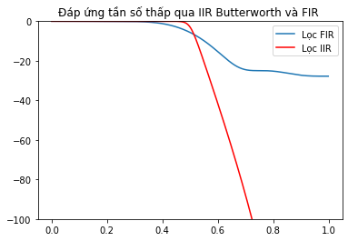

```python
b_fir = signal.firwin(15, 0.5, window="triang")
w, h = signal.freqz(b_fir, 1, worN=1024)

b_iir, a = signal.iirfilter(15, 0.5, rp=0.5, rs=50, btype='low',analog=False, ftype='butter')
w, H = signal.freqz(b_iir,a, worN=1024)
plt.title('Đáp ứng tần số thấp qua IIR Butterworth và FIR ')
plt.plot(w/np.pi, 20 * np.log10(abs(h)))
plt.plot(w/np.pi, 20*np.log10(abs(H)),'r')
plt.legend(["Lọc FIR", "Lọc IIR"])
plt.ylim(-100,0)
```

### Bài 6:

Cho tín hiệu x. Thực hiện mạch lọc IIR để  
a. Loại bỏ tín hiệu 0.5Hz và 2.5Hz.  
b. Chỉ giữ lại tần số 15.3Hz

Vẽ đáp ứng tần số của lọc (theo Hz). Vẽ tín hiệu vào và ra trên 1 hình

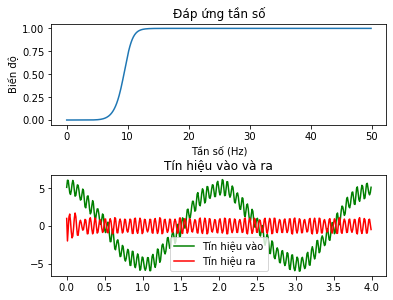

```python
sampleRate = 100 #Tần số lấy mẫu
nSamples = 400   #Số mẫu
t = np.arange(nSamples)/sampleRate #Khoảng thời gian
x = 5*np.cos(2*np.pi*0.5*t) + 0.2*np.sin(2*np.pi*2.5*t+0.1) + \
        np.sin(2*np.pi*15.3*t) + 0.1*np.sin(2*np.pi*18.7*t + 0.1) + \
            0.1*np.sin(2*np.pi*23.45*t+.8)
#Viết tiếp chương trình ở đây
#Câu a: Loại bỏ tần số 0.5Hz và 2.5Hz
tansocat = 10 #Hz  --> rad/s
tansoniquiz= sampleRate/2
Wn = tansocat/tansoniquiz
b, a = signal.iirfilter(8, Wn, rs=60, btype='high',analog=False, ftype='butter')
y = signal.lfilter(b, a, x)
w, H = signal.freqz(b, a, worN=512)
plt.subplot(2,1,1)
plt.plot((w/np.pi)*tansoniquiz, abs(H))
plt.title('Đáp ứng tần số')
plt.xlabel('Tần số (Hz)')
plt.ylabel('Biến độ')
plt.subplot(2,1,2)
plt.plot(t,x,'g')
plt.plot(t,y,'r')
plt.legend(['Tín hiệu vào' ,'Tín hiệu ra'])
plt.title('Tín hiệu vào và ra')
plt.subplots_adjust(top=1,hspace=0.5)
```

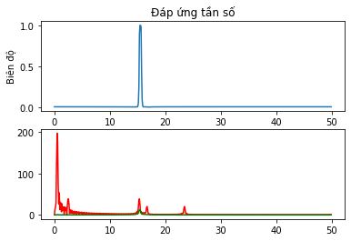

```python
#Câu b chỉ giữ lại tần số 15.3Hz
sampleRate = 100
nSamples = 400
t = np.arange(nSamples)/sampleRate
x = np.cos(2*np.pi*0.5*t) + 0.2*np.sin(2*np.pi*2.5*t+0.1) + 0.2*np.sin(2*np.pi*15.3*t) + 0.1*np.sin(2*np.pi*16.7*t + 0.1) + 0.1*np.sin(2*np.pi*23.45*t+.8)
tansonyquist= sampleRate/2
W1 = 15/tansonyquist
W2 = 16/tansonyquist

b, a = signal.iirfilter(4, Wn = [W1, W2], rs=50, btype='bandpass',analog=False, ftype='cheby2')
y = signal.lfilter(b, a, x)
w, H = signal.freqz(b,a, worN=512)
plt.subplot(2,1,1)
plt.plot((w/np.pi)*tansonyquist, abs(H))
plt.title("Đáp ứng tần số")
plt.xlabel('Hz')
plt.ylabel('Biên độ')
plt.subplot(2,1,2)
# plt.plot(t,x,'r')
# plt.plot(t,y,'g')
w, X = signal.freqz(x, 1, worN=512)
w_y, Y = signal.freqz(y, 1, worN=512)
plt.plot((w/np.pi)*tansonyquist, np.abs(X),'r')
plt.plot((w_y/np.pi)*tansonyquist, np.abs(Y),'g')
```

### Bài 7:

Cho file âm thanh gốc là "violin_origional.wav'" và file âm thanh gồm nhiễu "violin_noise.wav"  
a. Phân tích phổ của 2 file trên  
b. Xác định tần số của nhiễu  
c. Thiết kế mạch lọc IIR để loại nhiễu trong file "violin_noise.wav"  
d. So sánh với lọc FIR đã thực hiện ở bài trước

```python
 #Thư viện
from scipy.io import wavfile
from scipy import fftpack as fft
from scipy import signal
import IPython.display as ipd #Thêm thư viện để play Audio
# Đọc file
file_name= 'violin_origional.wav'
fs, s = wavfile.read(file_name)
#Sinh viên thêm đoạn code vào đây
#begin
#end
#Tạo file wav để nghe lại với y là tín hiệu sau lọc
y_wav = np.array(y, dtype='int16') #Định dạng lại âm thanh 16 bit
wavfile.write("violin_filtered.wav", fs,y_wav)
```

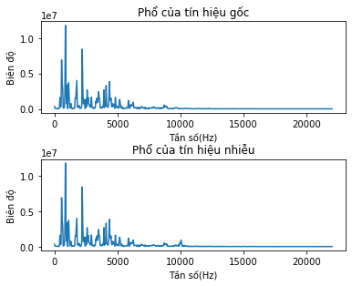

```python
#a Phân tích phổ của 2 tín hiệu
from scipy.io import wavfile
from scipy import fftpack as fft
from scipy import signal
import IPython.display as ipd #Thêm thư viện để play Audio
file_goc= 'violin_origional.wav'
file_nhieu= 'violin_noise.wav'
fs, s_goc = wavfile.read(file_goc)
ipd.Audio(s_goc, rate=fs)       #Phát Audio
fs, s_nhieu = wavfile.read(file_nhieu)
ipd.Audio(s_nhieu, rate=fs)       #Phát Audio
nyquistRate = fs/2
#Phân tích phổ
w, S_goc = signal.freqz(s_goc, 1, worN=512)
w, S_nhieu = signal.freqz(s_nhieu, 1, worN=512)
plt.subplot(2,1,1)
plt.plot((w/np.pi)*nyquistRate, np.abs(S_goc))
plt.title("Phổ của tín hiệu gốc")
plt.xlabel("Tần số(Hz)")
plt.ylabel("Biên độ")
plt.subplot(2,1,2)
plt.plot((w/np.pi)*nyquistRate, np.abs(S_nhieu))
plt.title("Phổ của tín hiệu nhiễu")
plt.xlabel("Tần số(Hz)")
plt.ylabel("Biên độ")
plt.subplots_adjust(top = 1, hspace = 0.5)
```

b. Trả lời: Tần số của nhiễu là 10kHz

[interactive chart not shown]

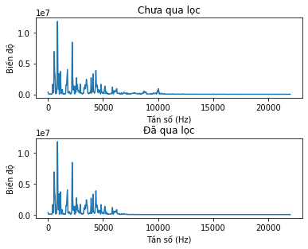

```python
#c. Thiết kế lọc và thực hiện lọc nhiễu
cutOffFreq = 9000   # chọn tần số cắt là 9kHz
wC = cutOffFreq/nyquistRate
b, a = signal.iirfilter(8, wC, rs=60, btype='low',analog=False, ftype='cheby2') # Dùng lọc thấp qua IIR loại Chebyshev II bậc 4, rs=60
s_loc = signal.lfilter(b, a, s_nhieu)  #tín hiệu s_nhieu lấy lại ở câu a

plt.subplot(2,1,1)
w, S_nhieu = signal.freqz(s_nhieu, 1, worN=512)
plt.plot((w/np.pi)*nyquistRate, abs(S_nhieu))
plt.title('Chưa qua lọc')
plt.xlabel('Tần số (Hz)')
plt.ylabel('Biến độ')

plt.subplot(2,1,2)
w, S_loc = signal.freqz(s_loc, 1, worN=512)
plt.plot((w/np.pi)*nyquistRate, abs(S_loc))
plt.title('Đã qua lọc')
plt.xlabel('Tần số (Hz)')
plt.ylabel('Biến độ')
plt.subplots_adjust(top = 1, hspace = 0.5)
ipd.Audio(s_loc, rate=fs)  # Phát lại audio sau khi lọc
```